# ETF轮动2.0

## 摘要

ETF动量轮动1.0版本选用纳指、黄金、沪深300、创指进行轮动，每日全仓某个ETF，波动性较大。

改进版本选取净值曲线整体向上的若干ETF分组轮动。

主要的难点在于ETF组合。第一、二组的逻辑较强：美股的成长性与黄金的避险性质互补、创业板和红利是两种重合度很低的资产，体现的是负相关性。第三种表现优秀，主要体现在低相关性。但是低相关性不是本质原因：低相关的资产组合很多，但有效的很少。这一点或许可以从学术角度研究，但有可能根本没有原因。

以下是几个子策略和整体策略的业绩指标

[output not shown]

```python
import warnings
warnings.filterwarnings('ignore')
import akshare as ak
import numpy as np
import pandas as pd
import quantstats as qs

%matplotlib inline
import matplotlib.pyplot as plt
import matplotlib.ticker as ticker

from itertools import combinations
```

## 基本函数

```python
# 初始化数据，计算窗口涨跌幅
def init_data(etf_symbols, window):
    etf_data = {}
    etf_symbols = etf_symbols

    # 获取 ETF 历史数据
    for symbol in etf_symbols:
        etf_df = ak.fund_etf_hist_em(symbol=symbol, period="daily", adjust='hfq')[['日期', '收盘']] \
                .rename(columns={'日期': 'date', '收盘': symbol}).set_index('date')
        etf_data[symbol] = etf_df

    # 合并数据并对齐
    data = pd.concat(list(etf_data.values()), axis=1).dropna()
    data.index = pd.to_datetime(data.index)

    # 计算每日涨跌幅和滚动收益率
    for symbol in etf_symbols:
        column_name = f"{symbol}"
        data[f"{column_name}_day_return"] = data[column_name].rolling(2).apply(lambda x: x[-1]/x[0]-1)
        data[f"{column_name}_return"] = data[column_name].rolling(window=window).apply(lambda x: x[-1]/x[0]-1)
        data[f"{column_name}_ma"] = data[column_name].rolling(window=window).mean()

    # 去掉缺失值
    data = data.dropna()

    return data

# 加入惰性，决定signal的值
def inert(etf_symbols, data, threshold):
    """
    输入初始化data和阈值，返回signal序列和调仓次数count
    """
    etf_symbols = etf_symbols
    signal_list = []
    count = 0
    prev_signal = None
    for i, (index, row) in enumerate(data.iterrows()):
        # 21日涨跌幅最大的基金
        tmp_signal = row[[f"{symbol}_return" for symbol in etf_symbols]].idxmax().split('_')[0]
        if i == 0:
            prev_signal = tmp_signal

        if tmp_signal != prev_signal:
            prev_ret = row[f"{prev_signal}_return"]
            tmp_ret = row[f"{tmp_signal}_return"]
            if prev_ret != 0:
                if np.abs(1-tmp_ret/prev_ret) > threshold:
                    prev_signal = tmp_signal
                    count = count + 1

        signal_list.append(prev_signal)

    return count, signal_list

# 止盈/止损，对signal_return进行调整
def stop(input_list, window_size, gain_threshold, loss_threshold, stop_period):
    for i in range(len(input_list)):
        if i >= window_size:
            window_sum = sum(input_list[i+1-window_size:i+1])
            if window_sum > gain_threshold:
                input_list.loc[input_list.index[i+1:i+1+stop_period]] = 0
            elif window_sum < loss_threshold:
                input_list.loc[input_list.index[i+1:i+1+stop_period]] = 0
    return input_list

# 枚举不同窗口值，计算各自的总收益率，画图
def find_window_size(etf_symbols, start=10, end=40):
    windows = np.arange(start, end)
    records = []
    etf_data = {}

    # 获取 ETF 历史数据
    for symbol in etf_symbols:
        etf_df = ak.fund_etf_hist_em(symbol=symbol, period="daily", adjust='hfq')[['日期', '收盘']] \
                .rename(columns={'日期': 'date', '收盘': symbol}).set_index('date')
        etf_data[symbol] = etf_df

    # 合并数据并对齐
    df = pd.concat(list(etf_data.values()), axis=1).dropna()
    df.index = pd.to_datetime(df.index)

    for window in windows:

        data = df.copy()

        # 计算每日涨跌幅和滚动收益率
        for symbol in etf_symbols:
            column_name = f"{symbol}"
            data[f"{column_name}_day_return"] = data[column_name].rolling(2).apply(lambda x: x[-1]/x[0]-1)
            data[f"{column_name}_return"] = data[column_name].rolling(window=window).apply(lambda x: x[-1]/x[0]-1)
            data[f"{column_name}_ma"] = data[column_name].rolling(window=window).mean()

        # 去掉缺失值
        data = data.dropna()

        count, data['signal'] = inert(etf_symbols, data, threshold=1.71)
        data['signal'] = data['signal'].shift(1)
        data = data.dropna()

        data["signal_return"] = (np.cumprod(data.apply(lambda row: row[f'{row["signal"]}_day_return'], axis=1) + 1) * 100)
        records.append(data["signal_return"][-1])

    fig, ax = plt.subplots(figsize=(15, 6))
    ax.set_xlabel('Window')
    ax.set_ylabel('Return')
    ax.plot(windows, records, marker='o')
    plt.title("Window size stability")
    plt.show()

# 输入一个时间范围，画区间收益率曲线
def period_curve(data, etf_symbols, start, end):
    fig, ax = plt.subplots(figsize=(15, 6))
    ax.set_xlabel('Time')
    ax.set_ylabel('Return')
    df = data[start:end]
    x = df["signal_return"].index
    y = df["signal_return"].values / df["signal_return"].values[0]
    for symbol in etf_symbols:
        yy = df[f"{symbol}_return"].values / df[f"{symbol}_return"].values[0]
        ax.plot(x, yy, label=symbol)

    ax.plot(x, y, label='signal')

    ax.legend(etf_symbols + ["signal"])
    ax.xaxis.set_major_locator(ticker.MultipleLocator(500))

# 画子策略收益率曲线，背景颜色表示持有资产，还包含原资产的曲线
def pnl_curve(etf_symbols, window_size=21):

    data = init_data(etf_symbols, window_size)

    count, data['signal'] = inert(etf_symbols, data, threshold=1.71)

    data['signal'] = data['signal'].shift(1)
    data = data.dropna()

    data["signal_return"] = (np.cumprod(data.apply(lambda row: row[f'{row["signal"]}_day_return'], axis=1) + 1) * 100)
    data = data.dropna()

    data['signal_day_return'] = data.apply(lambda row: row[f'{row["signal"]}_day_return'], axis=1)
    signal_day_return = data['signal_day_return'].copy()
    data['stop_gain_day_return'] = stop(signal_day_return, window_size=10, gain_threshold=0.2,
                                        loss_threshold=-0.15, stop_period=10)
    data["signal_return"] = np.cumprod(data['stop_gain_day_return'] + 1) * 100
    data['former_return'] = np.cumprod(data['signal_day_return'] + 1) * 100

    # 计算累计收益率
    for symbol in etf_symbols:
        column_name = f"{symbol}_return"
        data[column_name] = 100 * data[f"{symbol}"] / data[f"{symbol}"].values[0]

    print(f"累计收益率：{data.iloc[-1]['signal_return']}")
    print(f"调仓{count}次")

    # 绘制曲线图
    fig, ax = plt.subplots(figsize=(15, 6))
    ax.set_xlabel('Time')
    ax.set_ylabel('Return')

    for symbol in etf_symbols:
        ax.plot(data[f"{symbol}_return"].index, data[f"{symbol}_return"].values)
    ax.plot(data["signal_return"].index, data["signal_return"].values)
    ax.legend([*etf_symbols, "signal_return"])
    ax.xaxis.set_major_locator(ticker.MultipleLocator(200))

    # 定义色块颜色映射
    colors = ["blue", "orange", "green", "red"]
    color_map = {}
    for i, symbol in enumerate(etf_symbols):
        color_map[symbol] = colors[i]

    # 添加色块
    prev_signal = None
    for i, (index, row) in enumerate(data.iterrows()):
        current_signal = row['signal']
        if i == 0:
            prev_signal = current_signal
            continue

        color = color_map[current_signal]
        ax.axvspan(data.index[i - 1], index, facecolor=color, alpha=0.3)

        # 检查当前信号与前一个信号是否不同
        if current_signal != prev_signal:
            prev_signal = current_signal

    # 显示图形
    plt.show()

    return data
```

测试`window_size`部分都没用止盈/止损。

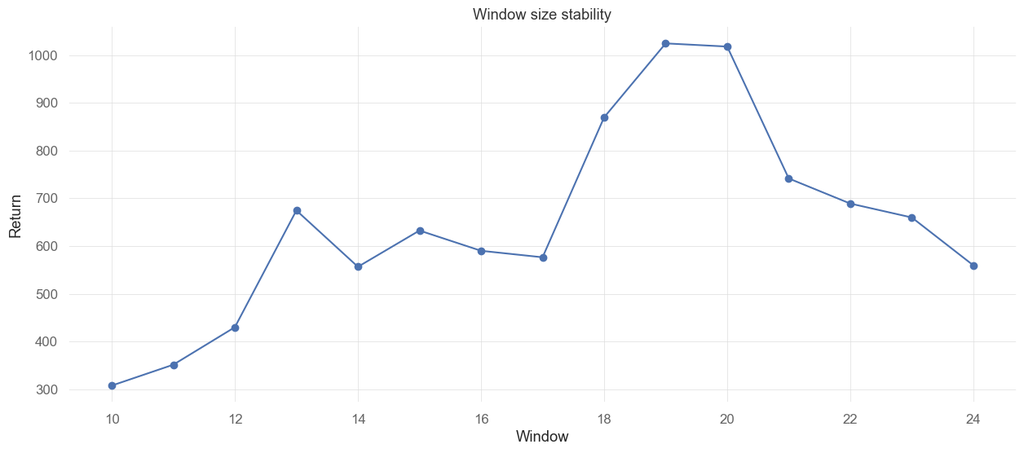

```python
find_window_size(['518880', '513100', '510300'], 10, 25)
```

```
累计收益率：1409.1992467423227
调仓128次
```

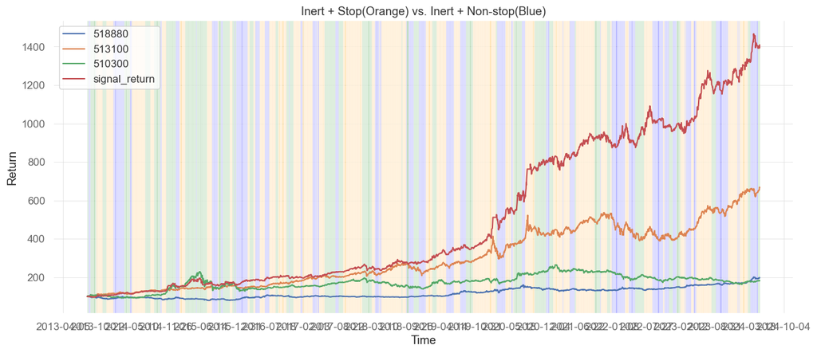

```python
etf_symbols_1 = ['518880', '513100', '510300']

# 第一个组合收益
first_data = pnl_curve(etf_symbols_1, 19)
first = first_data["signal_return"]
```

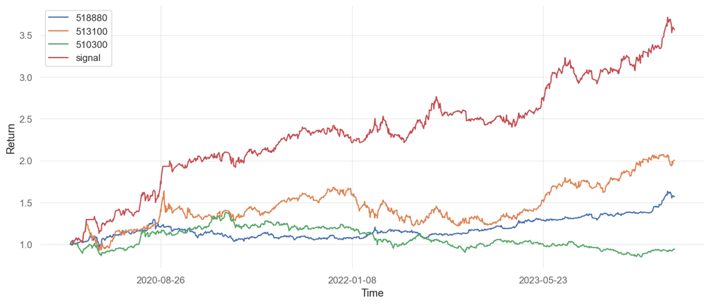

```python
start = '2020-1-1'
end = '2024-5-1'
period_curve(first_data, etf_symbols_1, start, end)
```

## 第二个组合：创指+红利低波

159915: 创业板指

512890: 红利低波

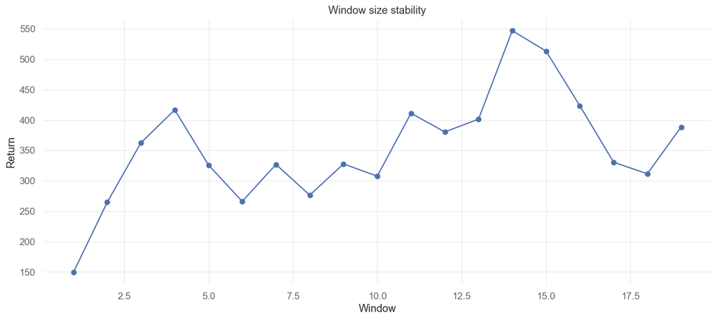

```python
find_window_size(['159915', '512890'], 1, 20)
```

```
累计收益率：603.675530165919
调仓42次
```

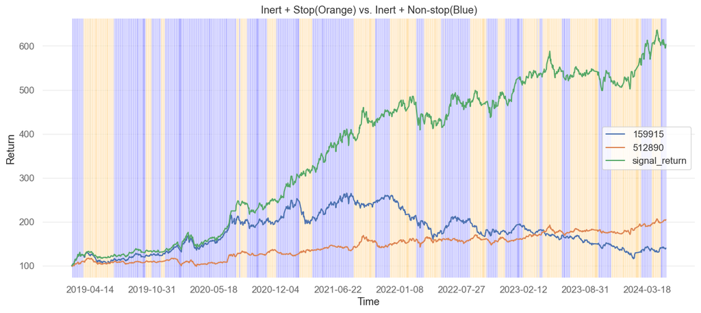

```python
etf_symbols_2 = ['159915', '512890']

# 第二个组合收益
second_data = pnl_curve(etf_symbols_2, 14)
second = second_data["signal_return"]
```

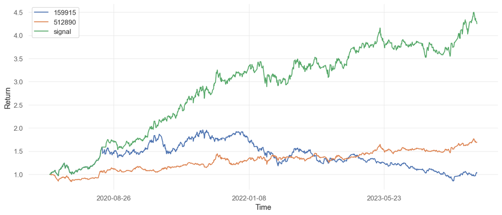

```python
start = '2020-1-1'
end = '2024-5-1'
period_curve(second_data, etf_symbols_2, start, end)
```

## 第三个组合：价值+日经+豆粕

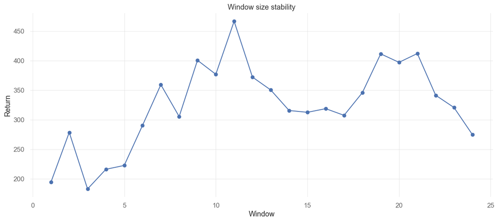

```python
find_window_size(['512040', '513520', '159985'], 1, 25)
```

```
累计收益率：517.1019503128931
调仓42次
```

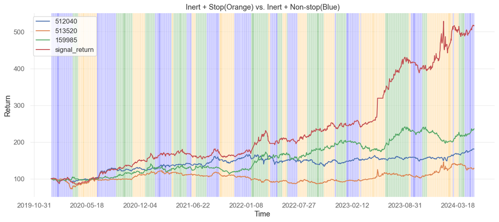

```python
# 第三个组合收益
etf_symbols_3 = ['512040', '513520', '159985']
third_data = pnl_curve(etf_symbols_3, 20)
third = third_data["signal_return"]
```

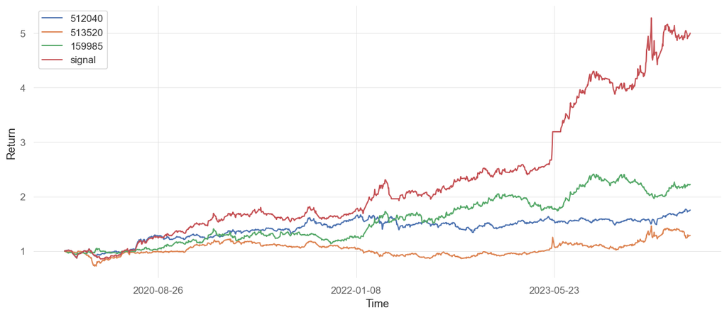

```python
start = '2020-1-1'
end = '2024-5-1'
period_curve(third_data, etf_symbols_3, start, end)
```

## 未完待续...

煤炭收益很高，看怎么处理

515220：煤炭

159980：有色

159945：能源

510410：资源

```python
# 能源, 大宗商品, 煤炭, 豆粕, 资源
etf_symbols = ["159980", "159981", "515600", "515680", "515900"]
data = init_data(etf_symbols, 21)

def find_combination(data):
    data = data.copy()
    num = len(etf_symbols)
    start_from = 2
    record = []
    for size in range(start_from, 4):
        for combination in combinations(range(num), size):
            codes = [etf_symbols[i] for i in combination]
            data['signal'] = inert(codes, data, threshold=1.71)[1]
            data['signal'] = data['signal'].shift(1)
            data = data.dropna()

            data["signal_return"] = (np.cumprod(data.apply(lambda row: row[f'{row["signal"]}_day_return'], axis=1) + 1) * 100)
            data = data.dropna()

            for code in codes:
                column_name = f"{code}_return"
                data[column_name] = 100 * data[f"{code}"] / data[f"{code}"].values[0]

            if data["signal_return"][-1] > np.max([data[f"{code}_return"][-1] for code in codes])+ 10:
                record.append(codes)
                print(data["signal_return"][-1],np.max([data[f"{code}_return"][-1] for code in codes]))

    return record

find_combination(data)
```

```
[]
```

港股通红利ETF

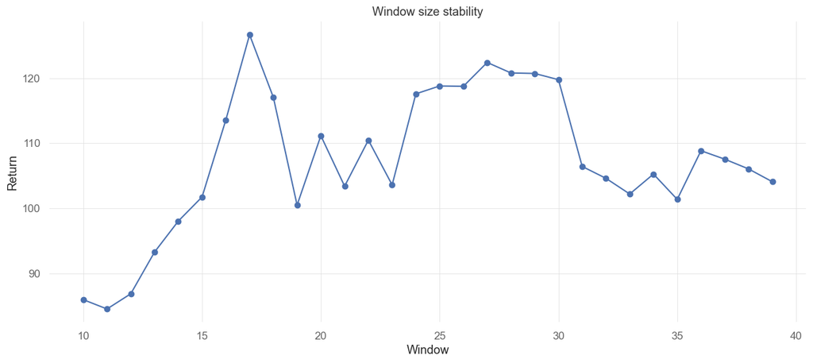

```python
find_window_size(["515220", "562350"])
```

```
累计收益率：133.73740676030286
调仓8次
```

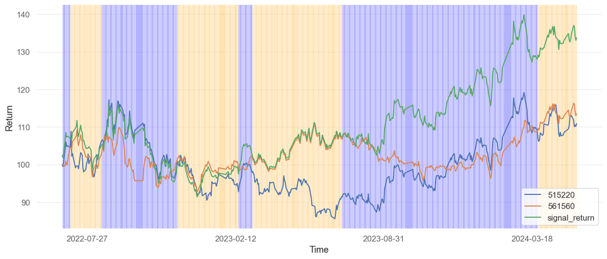

```python
etf_symbols_4 = ["515220", "561560"]
fourth_data = pnl_curve(etf_symbols_4, 27)
fourth = fourth_data["signal_return"]
```

## 等权组合

```python
# 等权组合收益
concat = pd.concat([first, second, third], axis=1)
names = ["first", "second", "third", "combine"]
concat.dropna(inplace=True)
concat = concat/concat.iloc[0]
concat['combine'] = np.mean(concat, axis=1)
concat.columns = names

# 景顺长城沪深港精选股票A
v = ak.fund_open_fund_info_em(symbol="000979").set_index("净值日期")
v.index = pd.to_datetime(v.index)
concat["000979"] = v["单位净值"]
concat["000979"] = concat["000979"]/concat["000979"][0]
```

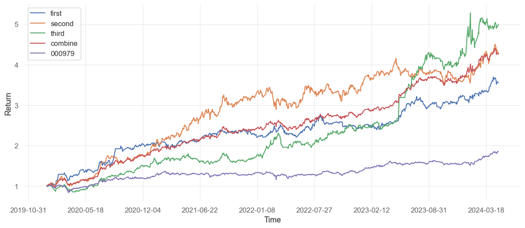

```python
fig, ax = plt.subplots(figsize=(15, 6))
ax.set_xlabel('Time')
ax.set_ylabel('Return')
start = '2020-1-1'
end = '2024-5-1'
df = concat[start:end]
x = df["combine"].index
for port in [*names, "000979"]:
    y = df[f"{port}"].values/df[f"{port}"].values[0]
    ax.plot(x, y, label=port)

ax.legend(concat.columns)
ax.xaxis.set_major_locator(ticker.MultipleLocator(200))
```

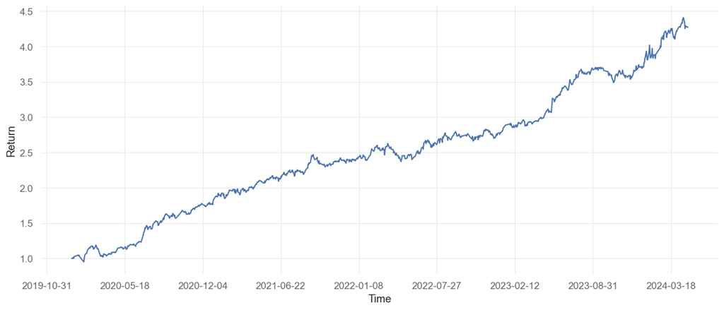

```python
fig, ax = plt.subplots(figsize=(15, 6))
ax.set_xlabel('Time')
ax.set_ylabel('Return')
df = concat[start:end]
x = df["combine"].index
y = df["combine"].values/df["combine"].values[0]
ax.plot(x, y)
ax.xaxis.set_major_locator(ticker.MultipleLocator(200))
```

```python
start = '2020-5-1'
end = '2024-5-1'
concat_partial = concat[start:end]

# 策略指标比较
measures = ["sharpe", "max_drawdown", "win_rate"]
port_list = [*names, "000979"]
result = np.zeros([len(measures),len(port_list)])

for i, measure in enumerate(measures):
    for j, port in enumerate(port_list):
        result[i][j] = getattr(qs.stats, measure)(concat_partial[f"{port}"])

result = pd.DataFrame(result)
result.index = measures
result.columns = port_list
result
```

|  | first | second | third | combine | 000979 |
| --- | --- | --- | --- | --- | --- |
| sharpe | 1.433781 | 1.628270 | 2.028381 | 2.316937 | 1.262049 |
| max_drawdown | -0.131263 | -0.157248 | -0.165460 | -0.097454 | -0.153800 |
| win_rate | 0.544102 | 0.519355 | 0.561538 | 0.568912 | 0.540773 |

## 执行策略

```
纳指+黄金：['518880', '513100']
创指+红利低波：['159915', '512890']
价值+日经+豆粕：['512040', '513520', '159985']
```

```python
import warnings
warnings.filterwarnings('ignore')
import akshare as ak
import numpy as np
import pandas as pd

def stop(input_list, window_size, gain_threshold, loss_threshold, stop_period):
    for i in range(len(input_list)):
        if i >= window_size:
            window_sum = sum(input_list[i+1-window_size:i+1])
            if window_sum > gain_threshold:
                input_list.loc[input_list.index[i+1:i+1+stop_period]] = 0
            elif window_sum < loss_threshold:
                input_list.loc[input_list.index[i+1:i+1+stop_period]] = 0
    return input_list

def get_position(etf_symbols, window):
    etf_data = {}

    # 获取 ETF 历史数据
    for symbol in etf_symbols:
        etf_df = ak.fund_etf_hist_em(symbol=symbol, period="daily", adjust='hfq')[['日期', '收盘']] \
                .rename(columns={'日期': 'date', '收盘': symbol}).set_index('date')
        etf_data[symbol] = etf_df

    # 合并数据并对齐
    data = pd.concat(list(etf_data.values()), axis=1).dropna()
    data.index = pd.to_datetime(data.index)

    # 计算每日涨跌幅和滚动收益率
    for symbol in etf_symbols:
        column_name = f"{symbol}"
        data[f"{column_name}_day_return"] = data[column_name].rolling(2).apply(lambda x: x[-1]/x[0]-1)
        data[f"{column_name}_return"] = data[column_name].rolling(window=window).apply(lambda x: x[-1]/x[0]-1)

    # 去掉缺失值
    data = data.dropna()

    signal_list = []
    prev_signal = None
    for i, (index, row) in enumerate(data.iterrows()):
        # 21日涨跌幅最大的基金
        tmp_signal = row[[f"{symbol}_return" for symbol in etf_symbols]].idxmax().split('_')[0]
        if i == 0:
            prev_signal = tmp_signal

        if tmp_signal != prev_signal:
            prev_ret = row[f"{prev_signal}_return"]
            tmp_ret = row[f"{tmp_signal}_return"]
            if np.abs(1-tmp_ret/prev_ret) > 1.71:
                prev_signal = tmp_signal

        signal_list.append(prev_signal)


    data['signal'] = signal_list
    nxt_day = data['signal'][-1]

    data['signal'] = data['signal'].shift(1)
    data = data.dropna()

    data['signal_day_return'] = data.apply(lambda row: row[f'{row["signal"]}_day_return'], axis=1)
    signal_day_return = data['signal_day_return'].copy()
    data['stop_gain_day_return'] = stop(signal_day_return, window_size=10, gain_threshold=0.2,
                                        loss_threshold=-0.15, stop_period=10)

    if -0.15 < data['stop_gain_day_return'][:10].sum() < 0.2:
        return nxt_day, data
    else:
        print(f"{etf_symbols} 清仓10天")


position1 = get_position(['518880', '513100'], 19)[0]
position2 = get_position(['159915', '512890'], 14)[0]
position3 = get_position(['512040', '513520', '159985'], 20)[0]
if position1 or position2 or position3:
    print(f"仓位1: {position1}")
    print(f"仓位2: {position2}")
    print(f"仓位3: {position3}")
```

```
仓位1: 513100
仓位2: 159915
仓位3: 159985
```